# Exploratory Data Analysis

This analysis explores the `application_train.csv` dataset to understand the class distribution, identify potential predictive signals, and inform feature engineering. The EDA also supports modeling strategy decisions by evaluating data quality, skew, and feature relationships.

## 1. Dataset Overview

- Total rows: ~307,511
- Total columns: 122
- Target variable: `TARGET` (binary classification)
  - `0` = no default
  - `1` = payment difficulty (default)

## 2. Class Imbalance

Roughly **8%** of applicants experienced payment difficulties.

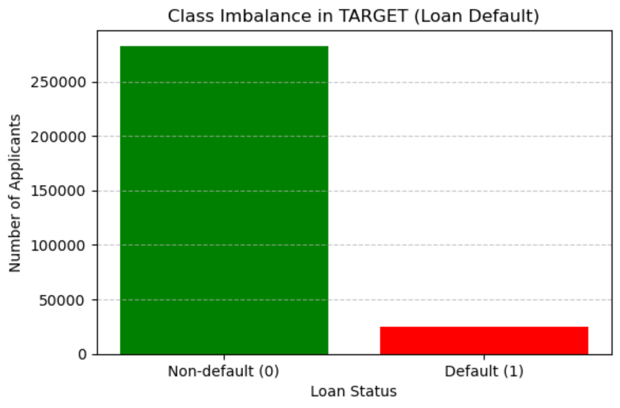

## 3. Missing Values

Significant missingness found in: - `OWN_CAR_AGE` - `EXT_SOURCE_1` - Building metadata: `*_AVG`, `*_MODE`, `*_MEDI` - Credit bureau request counts (`AMT_REQ_CREDIT_BUREAU_*`)

**Action Taken:** - Imputed using `SimpleImputer` (mean or median) - Dropped high-missingness building metadata features if low variance or importance

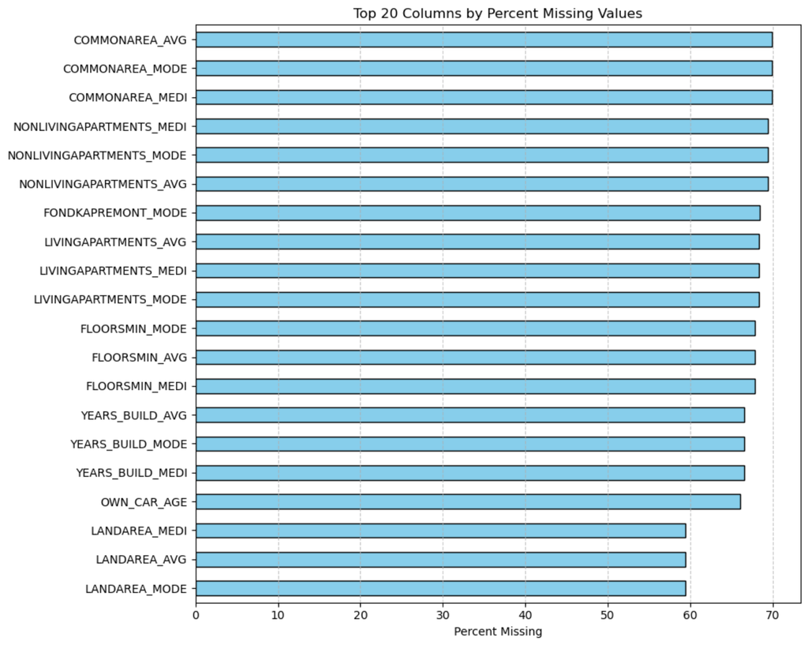

## 4. Numerical Feature Distributions

Key observations: - `AMT_INCOME_TOTAL` and `AMT_CREDIT` show heavy right skew - Most clients are aged 25–65 (via `DAYS_BIRTH`) - Skewed variables like income and credit were log-transformed

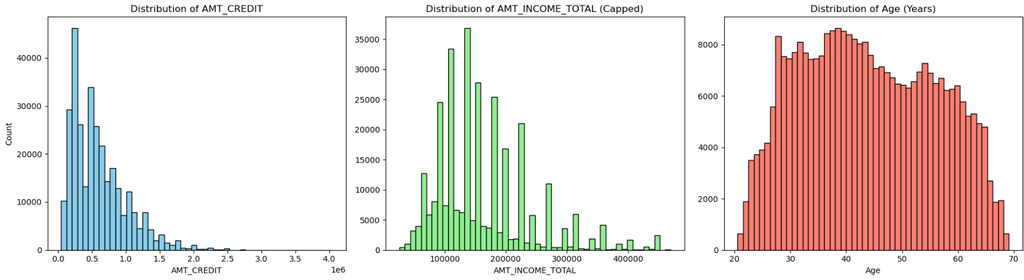

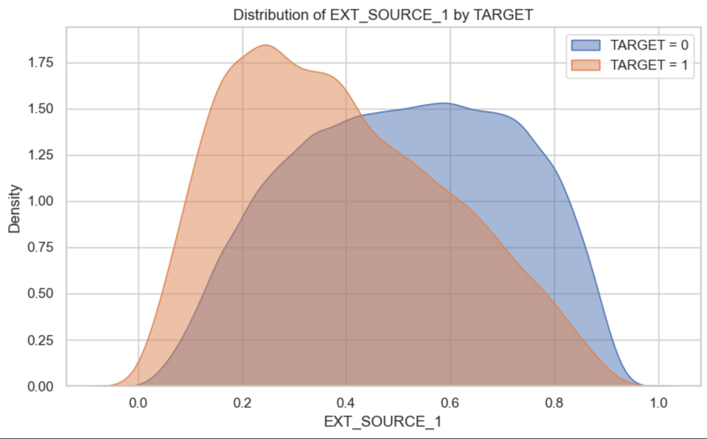

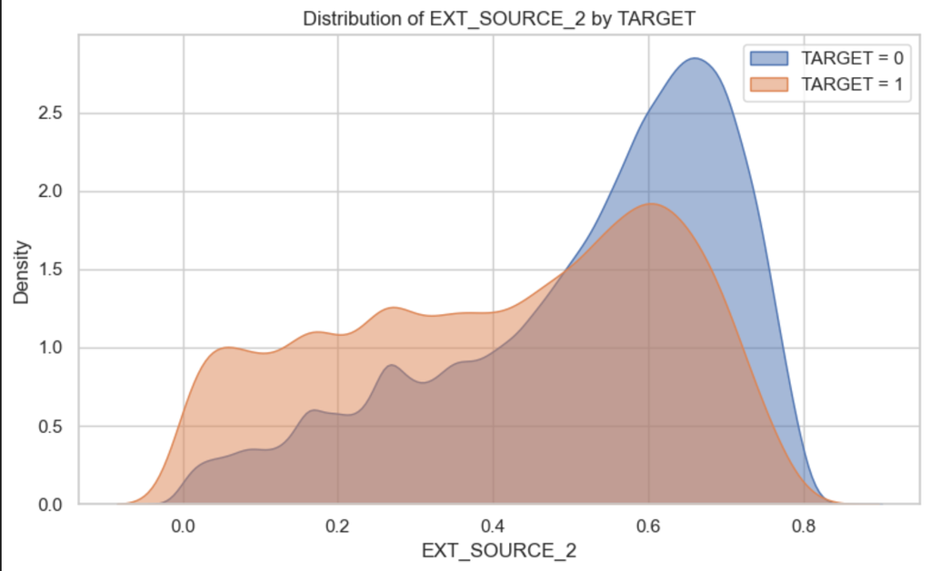

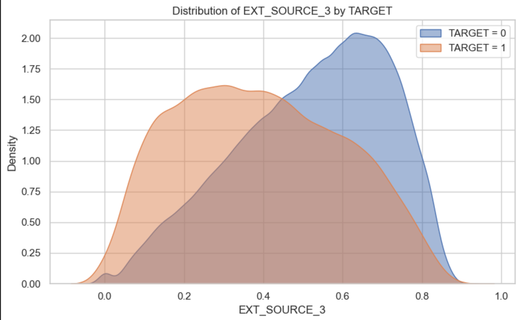

## 5. Categorical Variable Insights

Variables with clear class separation: - `NAME_CONTRACT_TYPE`: Cash loans correlate with higher default risk - `NAME_FAMILY_STATUS`: Singles tend to default more - `NAME_EDUCATION_TYPE`: Lower education correlates with higher default risk

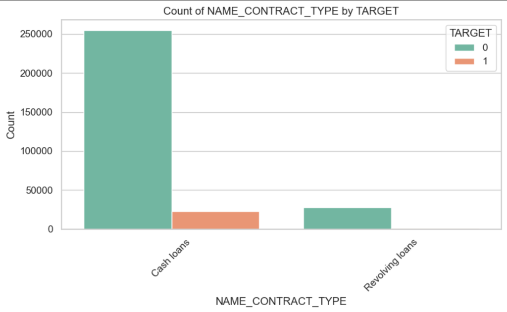

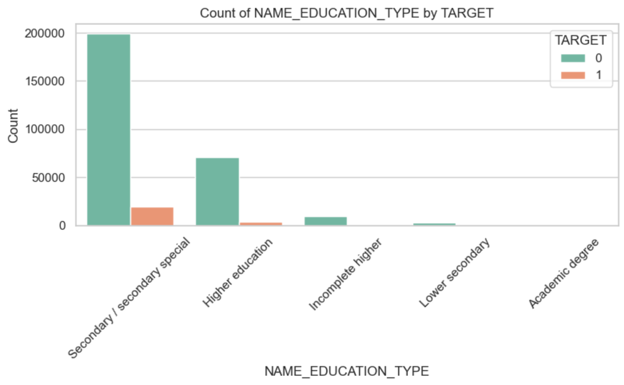

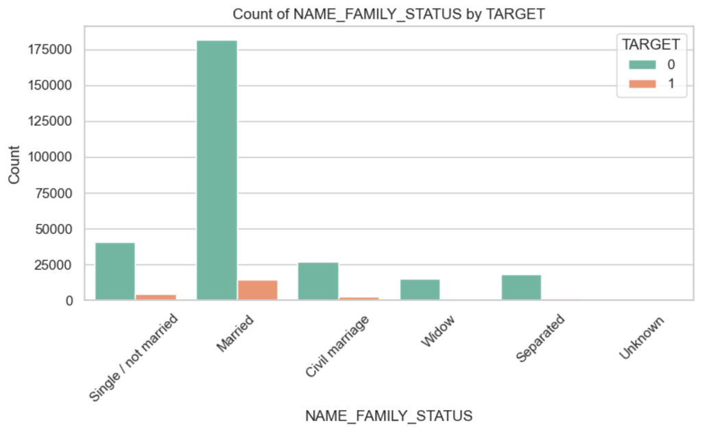

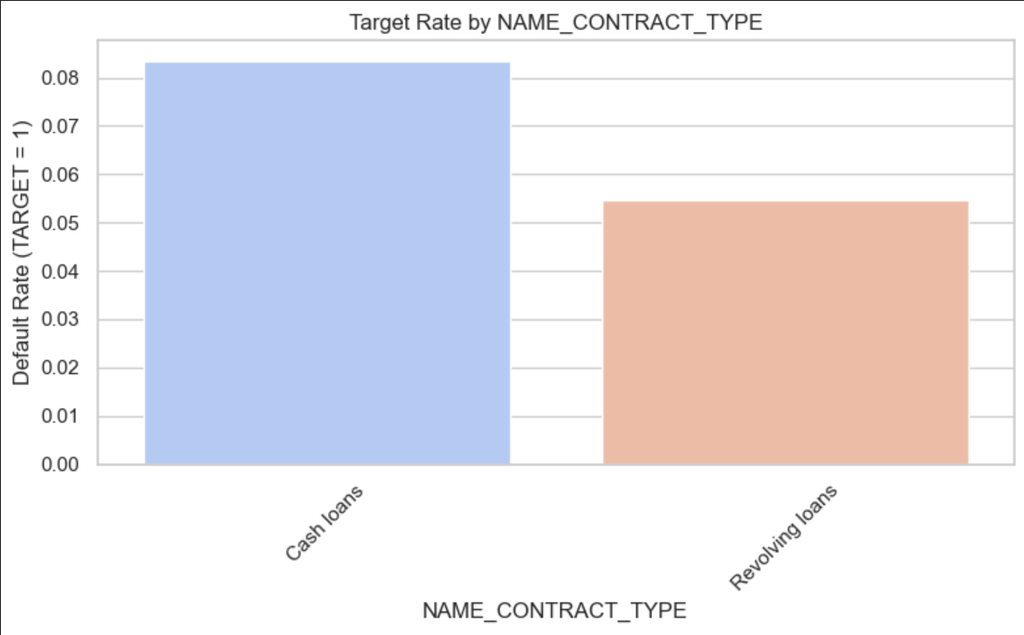

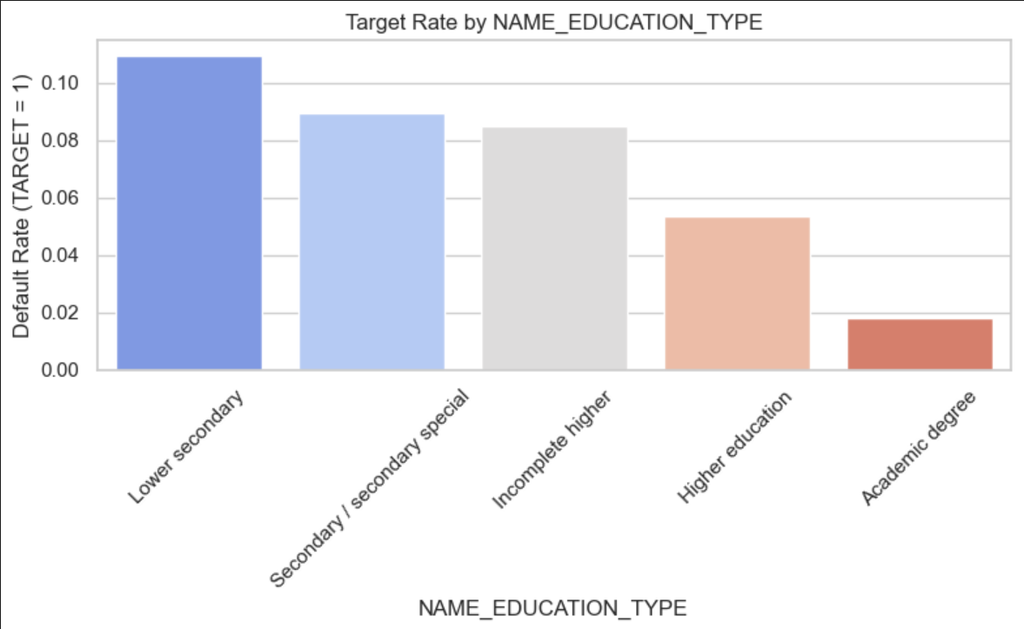

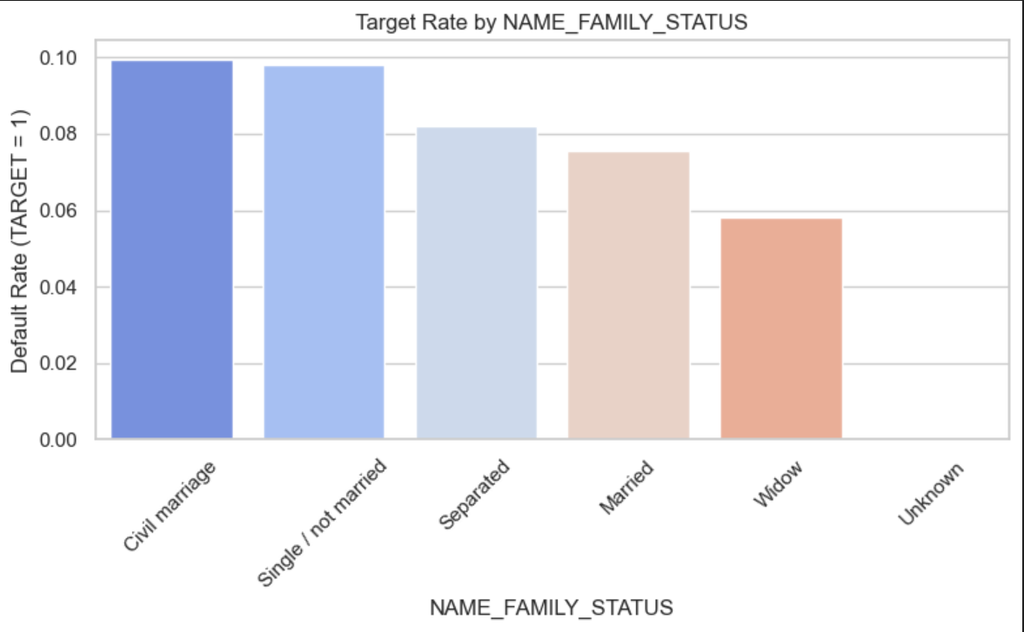

## 6. Correlation Analysis

**Interpretation:**  
Lower external scores and younger applicants have higher default rates.

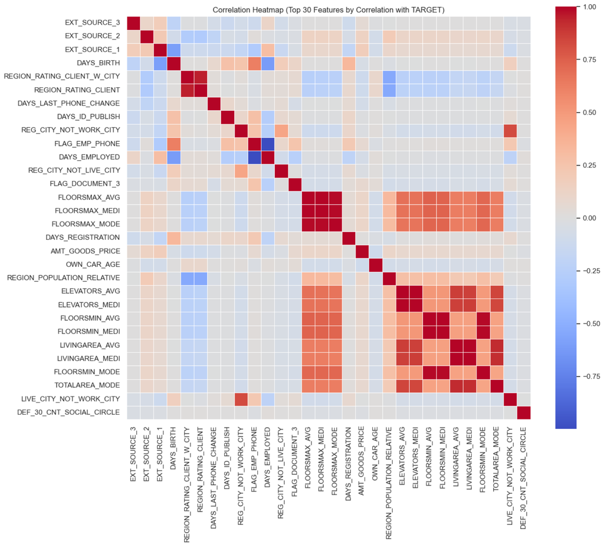

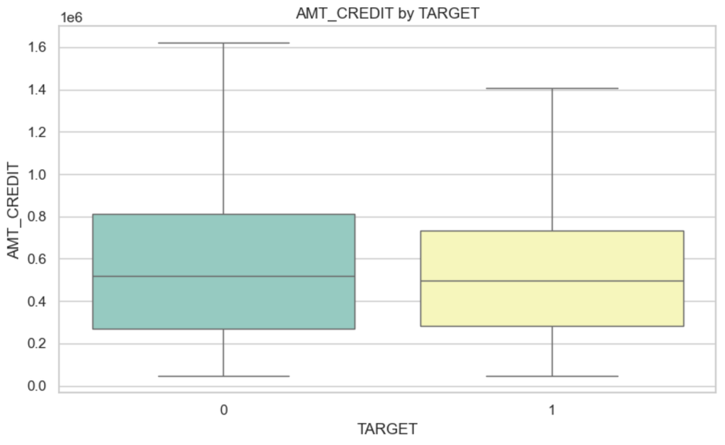

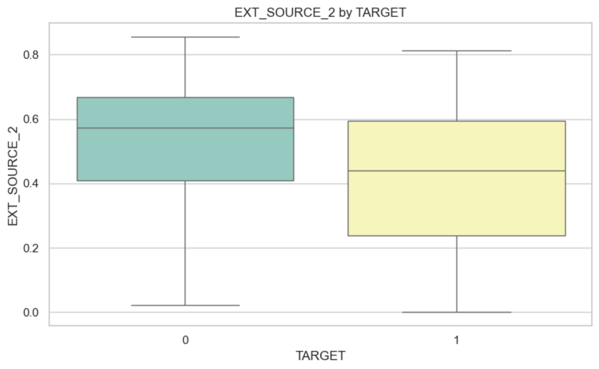

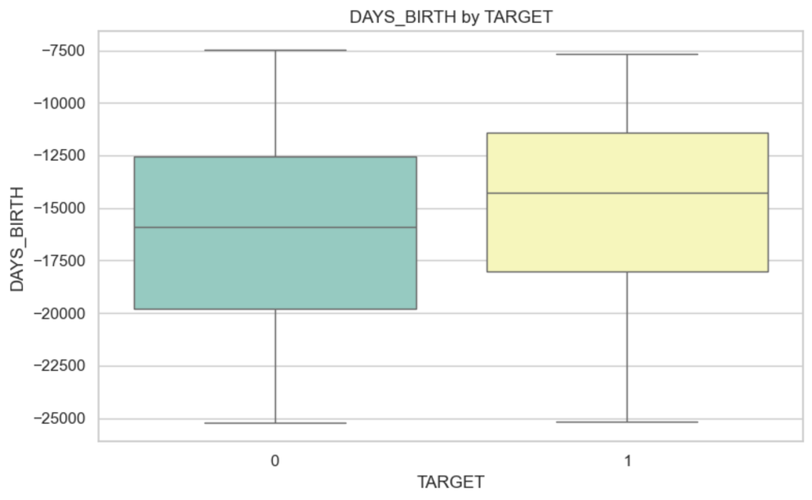

## 7. Bivariate Relationships

- Defaulting clients are generally younger
- Have lower EXT_SOURCE scores
- Often lower in income

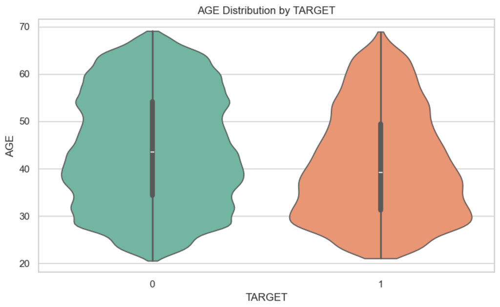

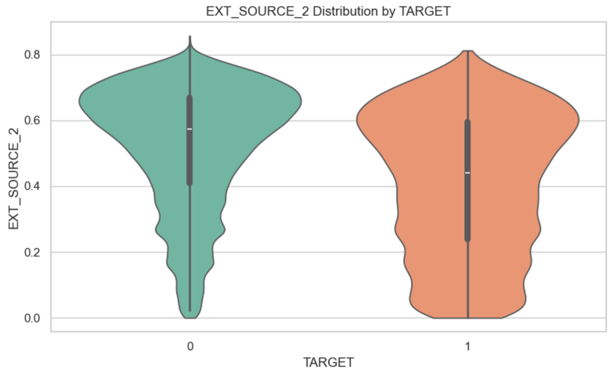

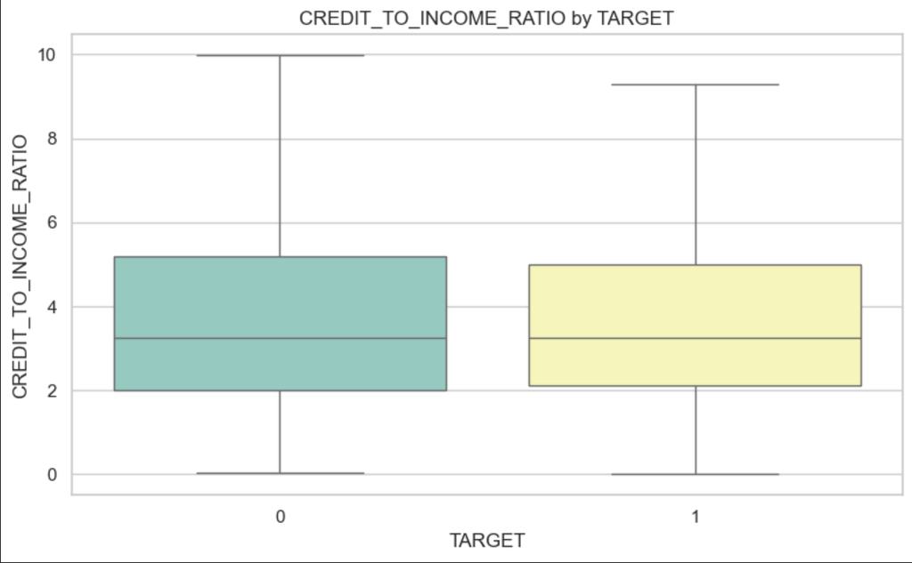

## 8. Feature Engineering Candidates

Proposed and implemented features based on EDA:

| Feature Name | Description |
| --- | --- |
| `CREDIT_TO_INCOME_RATIO` | AMT_CREDIT / AMT_INCOME_TOTAL |
| `ANNUITY_TO_INCOME_RATIO` | AMT_ANNUITY / AMT_INCOME_TOTAL |
| `EXT_SOURCES_MEAN` | Mean of EXT_SOURCE_1, 2, 3 |
| `DAYS_EMPLOYED_PERC` | DAYS_EMPLOYED / DAYS_BIRTH |
| `INCOME_PER_FAM_MEMBER` | AMT_INCOME_TOTAL / CNT_FAM_MEMBERS |

These were retained and validated via SHAP and F1-score improvements during model training.

## 9. Summary of EDA Findings

- **Target imbalance** is substantial and shaped modeling priorities
- **External risk scores** are the most predictive continuous features
- **Categorical variables** (contract type, education, family status) show clear stratification
- **Outliers and skew** addressed via log transforms and caps
- **High-missing features** handled with imputation or removal
- EDA directly informed ratio creation, SHAP grouping, and data prep for CatBoost

## 10. Next Steps

Leverage these insights in a unified feature engineering pipeline, merge relational tables, and evaluate performance impacts through stratified CV and SHAP-based model introspection.